# Ordenación no restringida

Kenneth Roy Cabrera Torres

20 de febrero de 2019

## Métodos de ordenación no restringido.

- Análisis de componentes principales (PCA).
  - Datos cuantitativos.
  - Preserva la distancia euclíedea.
- Análisis de correspondencia (CA).
  - Tabla de contingencia o valores cercanos a frecuencias.
  - Preserva la distancia $\chi^2$.
- Análisis de coordenadas principales (PCoA).
  - Orientado a matrices de disimilitud.
- Escalamiento multidimensional no métrico (NMDS).
  - Contrario a los anteriores no está basado en vectores propios.
  - Representa los objetos preservando la relaciones entre ellos.
  - Opera sobre matrices de disimilitud.

```r
## Paquetes
library(ade4)
library(vegan)
library(gclus)
library(ape)
library(missMDA)
library(FactoMineR)
library(tidyverse)
```

```r
# Funciones propias del libro.
# Ecología numérica.
source("cleanplot.pca.R")
source("PCA.newr.R")
source("CA.newr.R")
```

```r
# Lectura de las bases de datos.
ambient<-read.csv2("ambientales.csv",enc="latin1",row.names=1)
peces<-read.csv2("peces.csv",enc="latin1",row.names=1)
locs<-read.csv2("localidades.csv",enc="latin1",row.names=1)
nomEspec<-read.csv2("nombresdeespecies.csv",enc="latin1")
nomVarAmbient<-read.csv2("Nombresdevariablesambientales.csv",enc="latin1")
```

```r
# Adecuación
# Quitar el sitio que no tiene ninguna especie
sumEsp  <- apply(peces,1,sum)
peces   <- peces[sumEsp!=0,]
ambient <- ambient[sumEsp!=0,]
locs    <- locs[sumEsp!=0,]
```

```r
summary(ambient)
```

```
##       das             alt             slo             flo
##  Min.   :  0.3   Min.   :172.0   Min.   :1.099   Min.   :  84
##  1st Qu.: 70.5   1st Qu.:246.0   1st Qu.:1.792   1st Qu.: 480
##  Median :185.9   Median :375.0   Median :2.565   Median :2300
##  Mean   :193.0   Mean   :470.8   Mean   :2.740   Mean   :2292
##  3rd Qu.:304.3   3rd Qu.:752.0   3rd Qu.:3.434   3rd Qu.:2880
##  Max.   :453.0   Max.   :934.0   Max.   :6.176   Max.   :6900
##        pH             har              pho           nit
##  Min.   :7.700   Min.   : 40.00   Min.   :  1   Min.   : 15.0
##  1st Qu.:7.900   1st Qu.: 84.00   1st Qu.: 10   1st Qu.: 52.0
##  Median :8.000   Median : 88.00   Median : 30   Median :160.0
##  Mean   :8.048   Mean   : 85.83   Mean   : 57   Mean   :169.7
##  3rd Qu.:8.100   3rd Qu.: 97.00   3rd Qu.: 58   3rd Qu.:250.0
##  Max.   :8.600   Max.   :110.00   Max.   :422   Max.   :620.0
##       amm              oxy              bdo
##  Min.   :  0.00   Min.   : 41.00   Min.   : 13.00
##  1st Qu.:  0.00   1st Qu.: 81.00   1st Qu.: 27.00
##  Median : 10.00   Median :102.00   Median : 41.00
##  Mean   : 21.24   Mean   : 94.72   Mean   : 50.14
##  3rd Qu.: 20.00   3rd Qu.:110.00   3rd Qu.: 52.00
##  Max.   :180.00   Max.   :124.00   Max.   :167.00
```

## Componentes principales (PCA).

```r
ambient.pca <- rda(ambient, scale = TRUE)
ambient.pca
```

```
## Call: rda(X = ambient, scale = TRUE)
##
##               Inertia Rank
## Total              11
## Unconstrained      11   11
## Inertia is correlations
##
## Eigenvalues for unconstrained axes:
##   PC1   PC2   PC3   PC4   PC5   PC6   PC7   PC8   PC9  PC10  PC11
## 6.446 2.226 0.998 0.398 0.361 0.254 0.161 0.110 0.023 0.018 0.005
```

```r
summary(ambient.pca) # Default scaling 2
```

```
##
## Call:
## rda(X = ambient, scale = TRUE)
##
## Partitioning of correlations:
##               Inertia Proportion
## Total              11          1
## Unconstrained      11          1
##
## Eigenvalues, and their contribution to the correlations
##
## Importance of components:
##                         PC1    PC2     PC3    PC4     PC5    PC6     PC7
## Eigenvalue            6.446 2.2256 0.99817 0.3982 0.36108 0.2542 0.16118
## Proportion Explained  0.586 0.2023 0.09074 0.0362 0.03283 0.0231 0.01465
## Cumulative Proportion 0.586 0.7883 0.87904 0.9152 0.94807 0.9712 0.98583
##                           PC8      PC9     PC10      PC11
## Eigenvalue            0.11045 0.022951 0.017528 0.0049768
## Proportion Explained  0.01004 0.002086 0.001593 0.0004524
## Cumulative Proportion 0.99587 0.997954 0.999548 1.0000000
##
## Scaling 2 for species and site scores
## * Species are scaled proportional to eigenvalues
## * Sites are unscaled: weighted dispersion equal on all dimensions
## * General scaling constant of scores:  4.189264
##
##
## Species scores
##
##          PC1     PC2      PC3       PC4       PC5      PC6
## das  1.10770  0.4907 -0.20194  0.043203 -0.183449 -0.20321
## alt -1.06594 -0.5604  0.15120  0.194463  0.095799 -0.05629
## slo -0.95728 -0.5290 -0.25965 -0.352285  0.071789 -0.39538
## flo  0.98737  0.6262 -0.23733  0.008455 -0.106094 -0.31153
## pH  -0.02663  0.4992  1.14311 -0.015279 -0.003839 -0.17640
## har  0.91542  0.5519 -0.09620 -0.123348  0.639139  0.07366
## pho  1.02239 -0.6481  0.20001 -0.178625  0.042357 -0.04560
## nit  1.14048 -0.1630  0.05091 -0.284995 -0.272087  0.20276
## amm  0.96773 -0.7383  0.18731 -0.198644 -0.019671  0.04735
## oxy -0.99279  0.4993  0.04746 -0.543431 -0.007739  0.07087
```

[output cut: 20 more lines]

```
## 16 -0.16806  0.2503 -0.339756 -0.54189 -0.10245  0.61822
## 17  0.14888  0.3623 -0.171112 -0.14308 -0.14229  1.43505
## 18  0.08611  0.3670 -0.238163 -0.44140 -0.29135  1.01474
## 19  0.10946  0.4816  0.233055 -0.28859 -0.73364  0.93939
## 20  0.18559  0.3728 -0.268276 -0.69982 -0.97348  1.12449
## 21  0.16756  0.3110 -0.834150  0.21099 -0.71965  0.50465
## 22  0.13037  0.4841 -0.107885  0.18502 -0.28754 -0.57365
## 23  1.28520 -1.3163  0.715252 -0.56866  0.66305 -1.01398
## 24  1.01543 -0.4735  0.019439  1.43751  0.58740  0.14631
## 25  2.10064 -2.1405  0.360641 -1.21213 -0.17245  0.44142
## 26  0.89388 -0.1213 -0.671627  0.86377 -0.31342 -0.09211
## 27  0.61106  0.3180 -0.139301  0.30803 -0.81820 -0.97661
## 28  0.82375  0.8570  0.802400 -0.04908 -0.87639  0.04041
## 29  0.67822  1.0655 -1.729853  0.28668  0.29111 -1.02307
## 30  0.83489  1.4383  0.003559  0.93638  0.06777 -1.54091
```

```r
summary(ambient.pca, scaling = 1)
```

```
##
## Call:
## rda(X = ambient, scale = TRUE)
##
## Partitioning of correlations:
##               Inertia Proportion
## Total              11          1
## Unconstrained      11          1
##
## Eigenvalues, and their contribution to the correlations
##
## Importance of components:
##                         PC1    PC2     PC3    PC4     PC5    PC6     PC7
## Eigenvalue            6.446 2.2256 0.99817 0.3982 0.36108 0.2542 0.16118
## Proportion Explained  0.586 0.2023 0.09074 0.0362 0.03283 0.0231 0.01465
## Cumulative Proportion 0.586 0.7883 0.87904 0.9152 0.94807 0.9712 0.98583
##                           PC8      PC9     PC10      PC11
## Eigenvalue            0.11045 0.022951 0.017528 0.0049768
## Proportion Explained  0.01004 0.002086 0.001593 0.0004524
## Cumulative Proportion 0.99587 0.997954 0.999548 1.0000000
##
## Scaling 1 for species and site scores
## * Sites are scaled proportional to eigenvalues
## * Species are unscaled: weighted dispersion equal on all dimensions
## * General scaling constant of scores:  4.189264
##
##
## Species scores
##
##          PC1     PC2     PC3      PC4      PC5     PC6
## das  1.44706  1.0908 -0.6704  0.22706 -1.01253 -1.3369
## alt -1.39250 -1.2459  0.5019  1.02203  0.52876 -0.3703
## slo -1.25055 -1.1761 -0.8620 -1.85148  0.39623 -2.6011
## flo  1.28986  1.3920 -0.7879  0.04443 -0.58558 -2.0495
## pH  -0.03478  1.1099  3.7947 -0.08030 -0.02119 -1.1605
## har  1.19587  1.2270 -0.3193 -0.64827  3.52767  0.4846
## pho  1.33560 -1.4409  0.6640 -0.93879  0.23378 -0.3000
## nit  1.48987 -0.3624  0.1690 -1.49783 -1.50176  1.3339
## amm  1.26420 -1.6413  0.6218 -1.04400 -0.10857  0.3115
## oxy -1.29694  1.1101  0.1575 -2.85608 -0.04272  0.4662
```

[output cut: 20 more lines]

```
## 16 -0.12865  0.11258 -0.1023465 -0.103106 -0.01856  0.093971
## 17  0.11397  0.16296 -0.0515448 -0.027224 -0.02578  0.218130
## 18  0.06591  0.16506 -0.0717431 -0.083987 -0.05279  0.154243
## 19  0.08379  0.21662  0.0702043 -0.054910 -0.13292  0.142790
## 20  0.14207  0.16769 -0.0808142 -0.133157 -0.17637  0.170924
## 21  0.12827  0.13988 -0.2512752  0.040146 -0.13039  0.076708
## 22  0.09980  0.21775 -0.0324989  0.035204 -0.05210 -0.087196
## 23  0.98380 -0.59209  0.2154589 -0.108200  0.12013 -0.154128
## 24  0.77730 -0.21300  0.0058558  0.273518  0.10642  0.022239
## 25  1.60801 -0.96282  0.1086376 -0.230634 -0.03124  0.067096
## 26  0.68425 -0.05455 -0.2023175  0.164351 -0.05678 -0.014000
## 27  0.46776  0.14303 -0.0419622  0.058610 -0.14824 -0.148446
## 28  0.63057  0.38550  0.2417110 -0.009339 -0.15878  0.006142
## 29  0.51917  0.47928 -0.5210922  0.054548  0.05274 -0.155509
## 30  0.63909  0.64696  0.0010722  0.178166  0.01228 -0.234221
```

```r
?cca.object
```

```r
(ev <- ambient.pca$CA$eig)
```

```
##         PC1         PC2         PC3         PC4         PC5         PC6
## 6.445652783 2.225623134 0.998167248 0.398237743 0.361083244 0.254151119
##         PC7         PC8         PC9        PC10        PC11
## 0.161175284 0.110454275 0.022950910 0.017527507 0.004976752
```

### Criterio del modelo de la vara quebrada (broken stick model).

$$\lambda^* = \sum_{k = i}^p \frac{1}{k}$$
Donde:

$$\begin{eqnarray*}
\lambda^* & : & \text{El valor del valor propio del modelo de vara quebrada.} \\
p & & \text{Número de epsecies, (columnas).} \\
\end{eqnarray*}$$

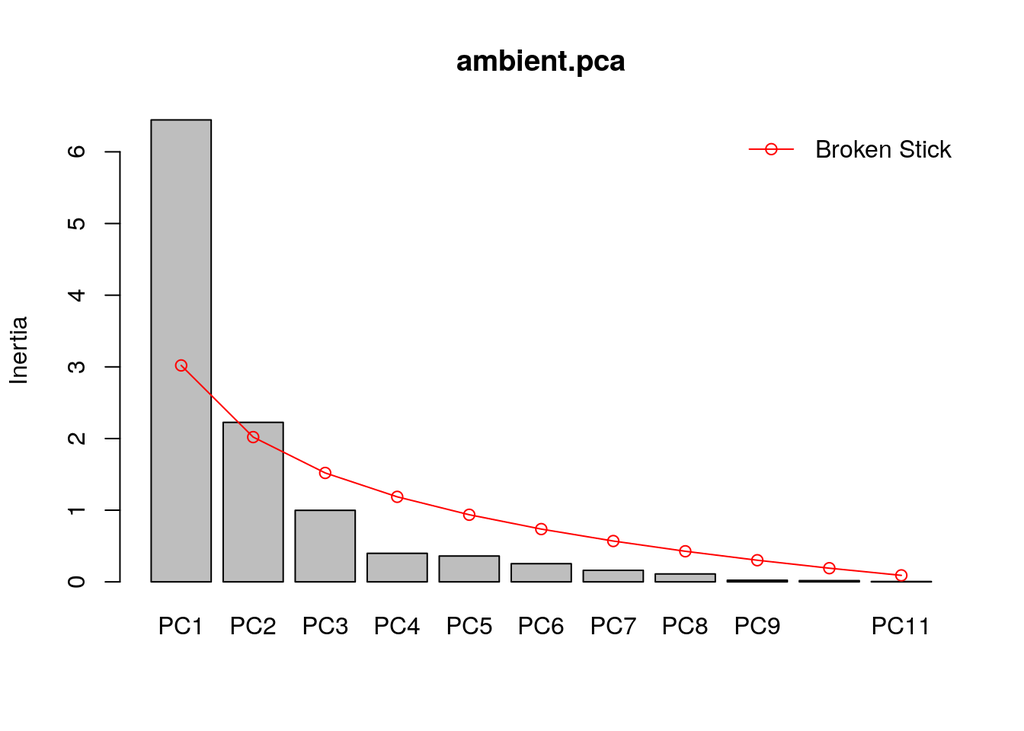

```r
screeplot(ambient.pca, bstick = TRUE, npcs = length(ambient.pca$CA$eig))
```

- **Escalamiento 1**: Óptimo para mostrar la relación de distancias entre objetos.
- **Escalamiento 2**: Óptimo para mostrar la correlación entre variables.

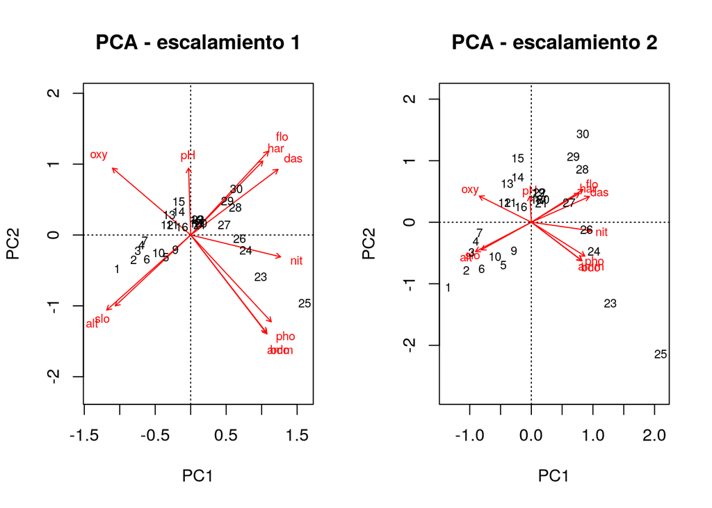

```r
op <- par(no.readonly = TRUE)
par(mfrow = c(1, 2))
biplot(ambient.pca, scaling = 1, main = "PCA - escalamiento 1")
biplot(ambient.pca, main = "PCA - escalamiento 2")
```

```r
par(op)
```

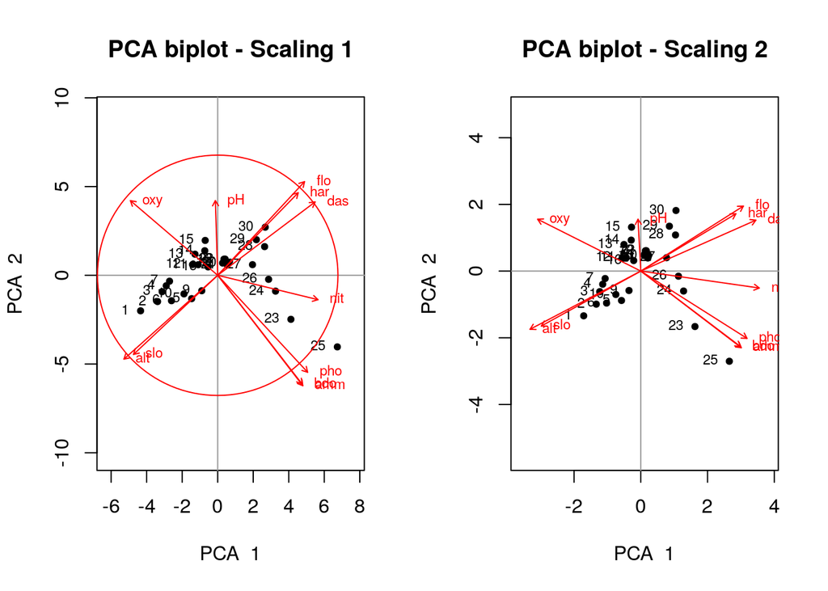

```r
par(mfrow = c(1, 2))
cleanplot.pca(ambient.pca, scaling = 1, mar.percent = 0.08)
cleanplot.pca(ambient.pca, scaling = 2, mar.percent = 0.04)
```

```r
par(op)
```

## Análisis de correpondencia (CA).

```r
# Compute CA
(peces.ca <- cca(peces))
```

```
## Call: cca(X = peces)
##
##               Inertia Rank
## Total           1.167
## Unconstrained   1.167   26
## Inertia is scaled Chi-square
##
## Eigenvalues for unconstrained axes:
##    CA1    CA2    CA3    CA4    CA5    CA6    CA7    CA8
## 0.6010 0.1444 0.1073 0.0834 0.0516 0.0418 0.0339 0.0288
## (Showing 8 of 26 unconstrained eigenvalues)
```

```r
summary(peces.ca)
```

```
##
## Call:
## cca(X = peces)
##
## Partitioning of scaled Chi-square:
##               Inertia Proportion
## Total           1.167          1
## Unconstrained   1.167          1
##
## Eigenvalues, and their contribution to the scaled Chi-square
##
## Importance of components:
##                         CA1    CA2     CA3     CA4     CA5     CA6     CA7
## Eigenvalue            0.601 0.1444 0.10729 0.08337 0.05158 0.04185 0.03389
## Proportion Explained  0.515 0.1237 0.09195 0.07145 0.04420 0.03586 0.02904
## Cumulative Proportion 0.515 0.6387 0.73069 0.80214 0.84634 0.88220 0.91124
##                           CA8     CA9     CA10     CA11     CA12     CA13
## Eigenvalue            0.02883 0.01684 0.010826 0.010142 0.007886 0.006123
## Proportion Explained  0.02470 0.01443 0.009278 0.008691 0.006758 0.005247
## Cumulative Proportion 0.93594 0.95038 0.959655 0.968346 0.975104 0.980351
##                           CA14     CA15     CA16     CA17     CA18
## Eigenvalue            0.004867 0.004606 0.003844 0.003067 0.001823
## Proportion Explained  0.004171 0.003948 0.003294 0.002629 0.001562
## Cumulative Proportion 0.984522 0.988470 0.991764 0.994393 0.995955
##                           CA19     CA20      CA21      CA22      CA23
## Eigenvalue            0.001642 0.001295 0.0008775 0.0004217 0.0002149
## Proportion Explained  0.001407 0.001110 0.0007520 0.0003614 0.0001841
## Cumulative Proportion 0.997362 0.998472 0.9992238 0.9995852 0.9997693
##                            CA24      CA25      CA26
## Eigenvalue            0.0001528 8.949e-05 2.695e-05
## Proportion Explained  0.0001309 7.669e-05 2.310e-05
## Cumulative Proportion 0.9999002 1.000e+00 1.000e+00
##
## Scaling 2 for species and site scores
## * Species are scaled proportional to eigenvalues
## * Sites are unscaled: weighted dispersion equal on all dimensions
##
##
## Species scores
##
```

[output cut: 47 more lines]

```
## 16  0.70214 -1.501167 -1.9735888  0.98502 -0.93585 -1.27168
## 17  0.28775 -0.836803 -1.2259108  0.73302 -1.57036  0.57315
## 18  0.05299 -0.647950 -0.9234228  0.35770 -0.95401  0.77738
## 19 -0.20584 -0.007252 -1.0154343  0.07041 -1.03450  0.51442
## 20 -0.57879  0.042849 -0.3660551 -0.15019 -0.61357  0.10115
## 21 -0.67320  0.038875  0.1194956  0.17256 -0.14686 -0.12018
## 22 -0.71933  0.014694  0.2204186  0.13598  0.09459 -0.02068
## 23 -0.70438  0.735398 -0.6546250 -6.61523 -2.49441 -1.73215
## 24 -0.83976  0.390120  0.5605295 -4.38864 -2.56916 -0.96702
## 25 -0.68476  0.418842 -0.2860819 -2.80336 -0.37540 -3.93791
## 26 -0.75808  0.210204  0.5894091 -0.70004 -0.01880 -0.10779
## 27 -0.75046  0.100869  0.5531191 -0.12946  0.29164  0.11280
## 28 -0.77878  0.088976  0.7379012  0.05204  0.40940  0.43236
## 29 -0.60815 -0.203235  0.5522726  0.43621  0.15010  0.25618
## 30 -0.80860 -0.019592  0.6686542  0.88136  0.52744  0.16456
```

```r
summary(peces.ca, scaling = 1)
```

```
##
## Call:
## cca(X = peces)
##
## Partitioning of scaled Chi-square:
##               Inertia Proportion
## Total           1.167          1
## Unconstrained   1.167          1
##
## Eigenvalues, and their contribution to the scaled Chi-square
##
## Importance of components:
##                         CA1    CA2     CA3     CA4     CA5     CA6     CA7
## Eigenvalue            0.601 0.1444 0.10729 0.08337 0.05158 0.04185 0.03389
## Proportion Explained  0.515 0.1237 0.09195 0.07145 0.04420 0.03586 0.02904
## Cumulative Proportion 0.515 0.6387 0.73069 0.80214 0.84634 0.88220 0.91124
##                           CA8     CA9     CA10     CA11     CA12     CA13
## Eigenvalue            0.02883 0.01684 0.010826 0.010142 0.007886 0.006123
## Proportion Explained  0.02470 0.01443 0.009278 0.008691 0.006758 0.005247
## Cumulative Proportion 0.93594 0.95038 0.959655 0.968346 0.975104 0.980351
##                           CA14     CA15     CA16     CA17     CA18
## Eigenvalue            0.004867 0.004606 0.003844 0.003067 0.001823
## Proportion Explained  0.004171 0.003948 0.003294 0.002629 0.001562
## Cumulative Proportion 0.984522 0.988470 0.991764 0.994393 0.995955
##                           CA19     CA20      CA21      CA22      CA23
## Eigenvalue            0.001642 0.001295 0.0008775 0.0004217 0.0002149
## Proportion Explained  0.001407 0.001110 0.0007520 0.0003614 0.0001841
## Cumulative Proportion 0.997362 0.998472 0.9992238 0.9995852 0.9997693
##                            CA24      CA25      CA26
## Eigenvalue            0.0001528 8.949e-05 2.695e-05
## Proportion Explained  0.0001309 7.669e-05 2.310e-05
## Cumulative Proportion 0.9999002 1.000e+00 1.000e+00
##
## Scaling 1 for species and site scores
## * Sites are scaled proportional to eigenvalues
## * Species are unscaled: weighted dispersion equal on all dimensions
##
##
## Species scores
##
```

[output cut: 47 more lines]

```
## 16  0.54432 -0.570386 -0.6464636  0.284420 -0.212539 -0.26014
## 17  0.22308 -0.317953 -0.4015561  0.211655 -0.356642  0.11725
## 18  0.04108 -0.246196 -0.3024740  0.103285 -0.216664  0.15902
## 19 -0.15958 -0.002755 -0.3326130  0.020330 -0.234943  0.10523
## 20 -0.44870  0.016281 -0.1199041 -0.043366 -0.139347  0.02069
## 21 -0.52189  0.014771  0.0391417  0.049826 -0.033352 -0.02458
## 22 -0.55765  0.005583  0.0721997  0.039264  0.021482 -0.00423
## 23 -0.54606  0.279423 -0.2144273 -1.910111 -0.566501 -0.35434
## 24 -0.65102  0.148231  0.1836056 -1.267193 -0.583479 -0.19782
## 25 -0.53085  0.159144 -0.0937082 -0.809453 -0.085257 -0.80556
## 26 -0.58769  0.079869  0.1930653 -0.202133 -0.004271 -0.02205
## 27 -0.58178  0.038326  0.1811782 -0.037380  0.066234  0.02307
## 28 -0.60374  0.033808  0.2417050  0.015027  0.092978  0.08844
## 29 -0.47146 -0.077222  0.1809010  0.125954  0.034090  0.05241
## 30 -0.62686 -0.007444  0.2190226  0.254487  0.119787  0.03366
```

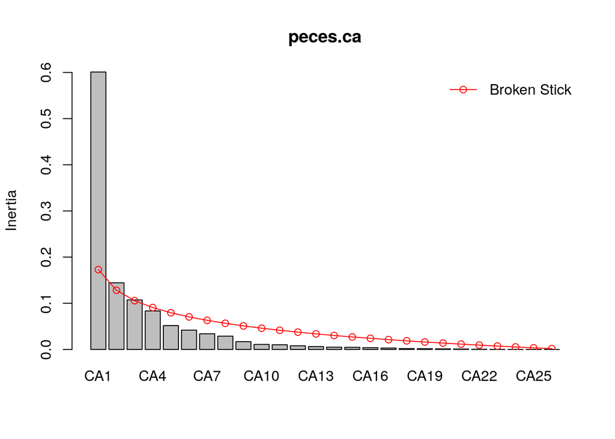

```r
screeplot(peces.ca, bstick = TRUE, npcs = length(peces.ca$CA$eig))
```

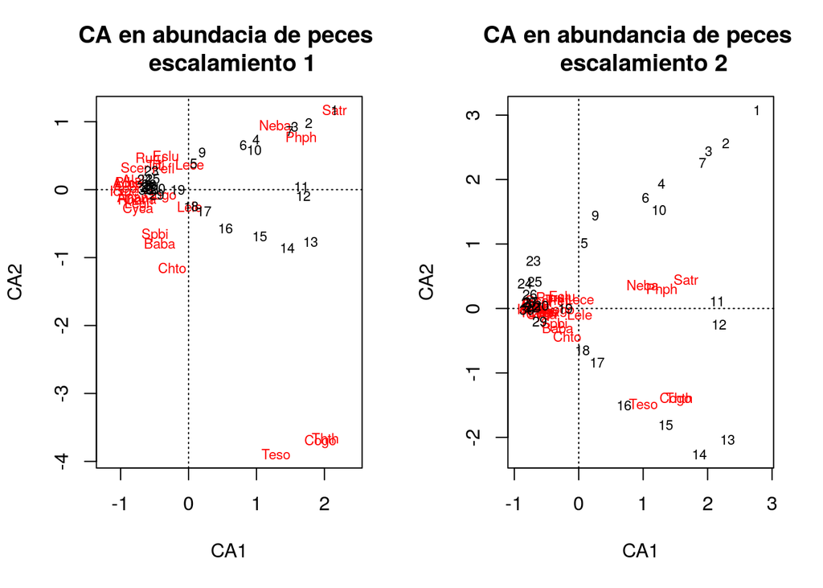

```r
op <- par(no.readonly = TRUE)
par(mfrow = c(1, 2))
# Scaling 1: los sitios son centroides de las species.
plot(peces.ca,
     scaling = 1,
     main = "CA en abundacia de peces \n escalamiento 1"
)
# Scaling 2 (default): las especies son centroides de los sitios.
plot(peces.ca, main = "CA en abundancia de peces \n escalamiento 2")
```

```r
par(op)
```

## Análisis de coordenadas principales (PCoA).

```r
peces.bray <- vegdist(peces)
peces.b.pcoa <- cmdscale(peces.bray, k = (nrow(peces) - 1), eig = TRUE)
```

```r
ordiplot(scores(peces.b.pcoa, choices = c(1, 2)),
         type = "t",
         main = "PCoA con promedios ponderados de especies")
```

```
## species scores not available
```

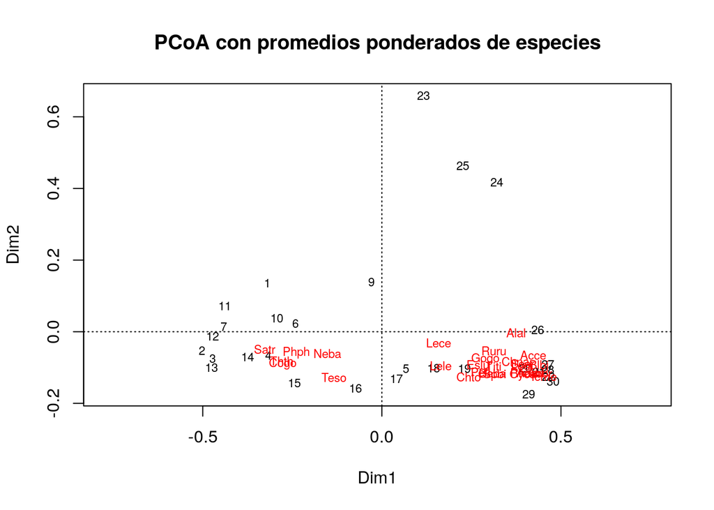

```r
abline(h = 0, lty = 3)
abline(v = 0, lty = 3)
peces.wa <- wascores(peces.b.pcoa$points[, 1:2], peces)
text(peces.wa, rownames(peces.wa), cex = 0.7, col = "red")
```

## Escalamiento multidimensional no métrico.

```r
peces.nmds <- metaMDS(peces, distance = "bray")
```

```
## *** Solution reached
```

```r
peces.nmds
```

```
##
## Call:
## metaMDS(comm = peces, distance = "bray")
##
## global Multidimensional Scaling using monoMDS
##
## Data:     peces
## Distance: bray
##
## Dimensions: 2
## Stress:     0.07376256
## Stress type 1, weak ties
## Two convergent solutions found after 20 tries
## Scaling: centring, PC rotation, halfchange scaling
## Species: expanded scores based on 'peces'
```

```r
peces.nmds$stress
```

```
## [1] 0.07376256
```

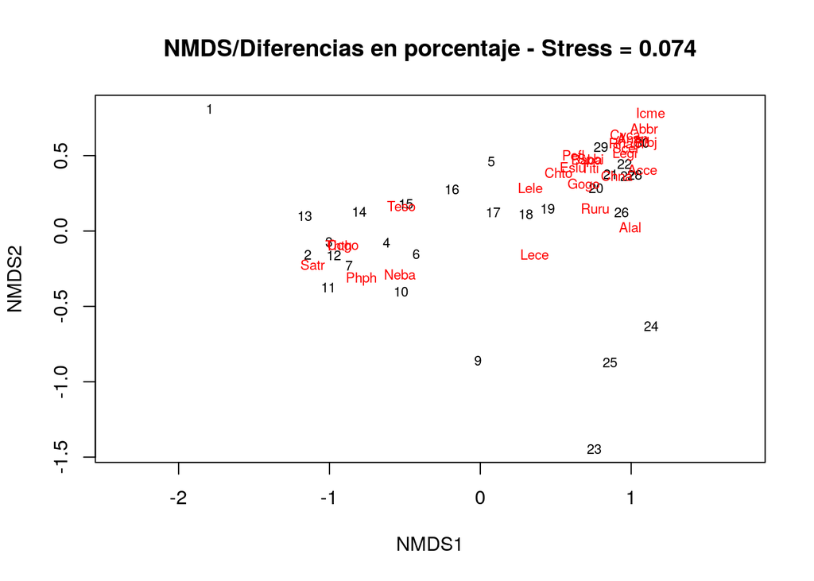

```r
plot(
  peces.nmds,
  type = "t",
  main = paste(
    "NMDS/Diferencias en porcentaje - Stress =",
    round(peces.nmds$stress, 3)
  )
)
```

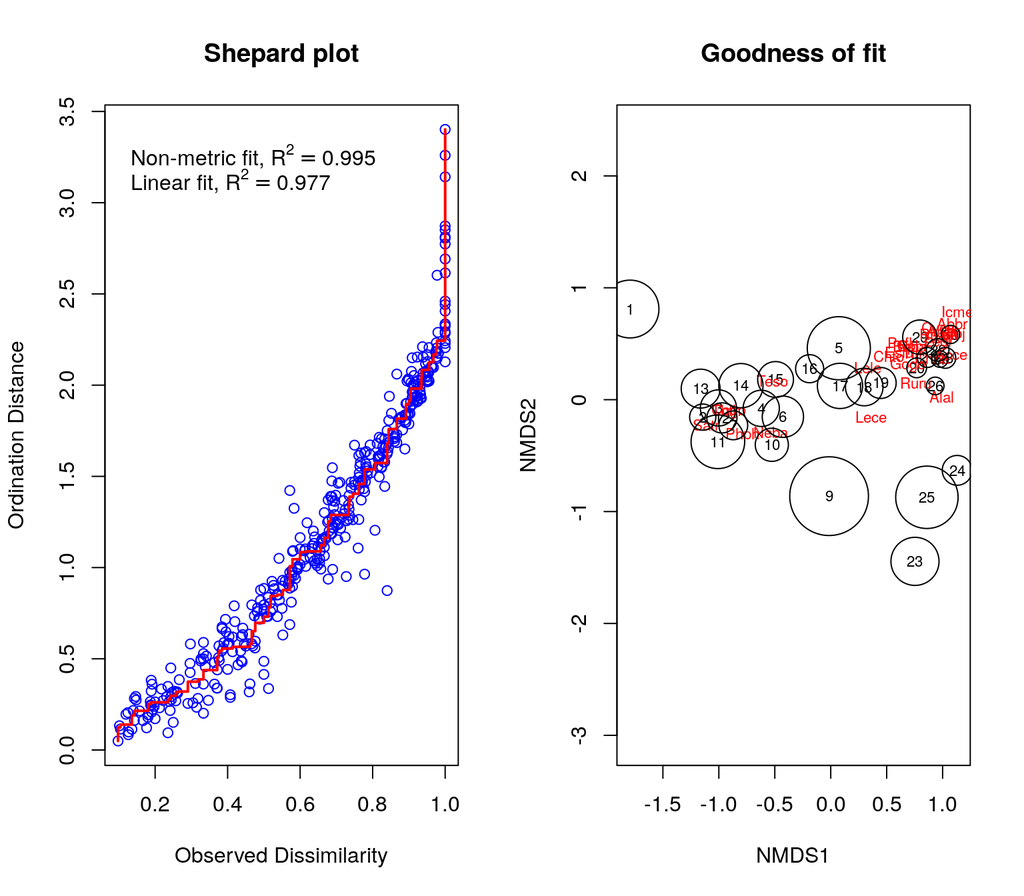

```r
op <- par(no.readonly = TRUE)
par(mfrow = c(1, 2))
stressplot(peces.nmds, main = "Shepard plot")
gof <- goodness(peces.nmds)
plot(peces.nmds, type = "t", main = "Goodness of fit")
points(peces.nmds, display = "sites", cex = gof * 300)
```

```r
par(op)
```

## Comparación de los métodos PCoA vs NMDS.

### NMDS.

- Dependiendo del punto de partida puede cambiar la soluición.
- Las disimilitudes o distancias se distorsionan.
- Los primeros ejes no maximizan la varianza de las observaciones.
- El criterio de optimización puede cambiar.
- Sólo los expertos puede establecer que cambios en argumentos de las funciones NMDS cambia la solución.
- La selección de la dimensión a proyectar, pero las soluciones no son exactas para valores bajos de dimensión.
- El estadístico de “stress” no es un indicador de la proporción de varianza. Indica la deformación de las disimilitudes con respecto a las originales.

### PCoA.

- PCoA encuentra una solución óptima de valores y vectores propios. La solución es única.
- Las disimilitudes no se distorcionan en la solución completa.
- El primer eje maximiza la varianza de las observaciones.
- La solución de la ordenación es exacta.
- Se puede reproducir las distancias originales usando todos los ejes del PCoA.
- Se puede establecer la proporción de varianza que cada eje explica.